# Introduction to using R package: `spBFA`

Samuel I. Berchuck

2019-10-25

## Use of `spBFA`

This is a brief description of how to use the `spBFA` package within the context of glaucoma progression. To demonstrate the method we use the `VFSeries` data set from the `womblR` package. We begin by loading the packages.

```r
library(womblR)
library(spBFA)
```

The data object `VFSeries` has four variables, `Visit`, `DLS`, `Time` and `Location`. The data object loads automatically; here’s what the data looks like,

```r
head(VFSeries)
```

```
##   Visit DLS Time Location
## 1     1  25    0        1
## 2     2  23  126        1
## 3     3  23  238        1
## 4     4  23  406        1
## 5     5  24  504        1
## 6     6  21  588        1
```

The variable `Visit` represents the visual field test visit number, `DLS` the observed outcome variable, differential light sensitivity, `Time` the time of the visual field test (in days from baseline visit) and `Location` the spatial location on the visual field that the observation occurred. To help illuminate visual field data we can use the `PlotVFTimeSeries` function from the `womblR` package. `PlotVFTimeSeries` is a function that plots the observed visual field data over time at each location on the visual field.

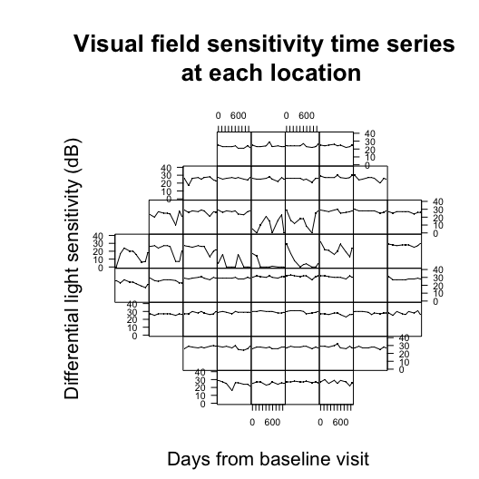

```r
PlotVfTimeSeries(Y = VFSeries$DLS,
                 Location = VFSeries$Location,
                 Time = VFSeries$Time,
                 main = "Visual field sensitivity time series \n at each location",
                 xlab = "Days from baseline visit",
                 ylab = "Differential light sensitivity (dB)",
                 line.col = 1, line.type = 1, line.reg = FALSE)
```

The figure above demonstrates the visual field from a Humphrey Field Analyzer-II testing machine, which generates 54 spatial locations (only 52 informative locations, note the 2 blanks spots corresponding to the blind spot). At each visual field test a patient is assessed for vision loss.

## Format data for `spBFA`

We can now begin to think about preparing objects for use in the Bayesian spatial factor analysis function (`bfa_sp`). According to the manual, we use a `formula` specification for the observed data, where the data must be first ordered spatially and then temporally (We only use on spatial observation type in this example, thus `O` is one.). Furthermore, we will remove all locations that correspond to the natural blind spot (which in the Humphrey Field Analyzer-II correspond to locations 26 and 35).

```r
blind_spot <- c(26, 35) # define blind spot
VFSeries <- VFSeries[order(VFSeries$Location), ] # sort by location
VFSeries <- VFSeries[order(VFSeries$Visit), ] # sort by visit
VFSeries <- VFSeries[!VFSeries$Location %in% blind_spot, ] # remove blind spot locations
dat <- data.frame(Y = VFSeries$DLS / 10) # create data frame with scaled data
```

Now that we have assigned the observed outcome we move onto the temporal variable `time`. For visual field data we define this to be the time from the baseline visit. We obtain the unique days from the baseline visit and scale them to be on the year scale.

```r
Time <- unique(VFSeries$Time) / 365 # years since baseline visit
print(Time)
```

```
## [1] 0.0000000 0.3452055 0.6520548 1.1123288 1.3808219 1.6109589 2.0712329
## [8] 2.3780822 2.5698630
```

Our example patient has nine visual field visits and the last visit occurred 2.57 years after the baseline visit.

## Adjacency matrix

We now specify the adjacency matrix, `W`, for our areal data analysis. We use the `HFAII_Queen` adjacency matrix for visual fields, provided in `womblR`. This is an adjacency matrix that defines an adjacency as edges and corners (i.e., the movements of a queen in chess). The adjacency objects are preloaded and contain the blind spot, so we define our adjacency matrix as follows.

```r
W <- HFAII_Queen[-blind_spot, -blind_spot] # visual field adjacency matrix
M <- dim(W)[1] # number of locations
```

Now that we have specified the data objects, we will customize the objects that characterize Bayesian Markov chain Monte Carlo (MCMC) methods, in particular hyperparameters, starting values, metropolis tuning values and MCMC inputs.